# Lab 1 solution

# Lab 1 Instructions

In this week’s lab, the main goal is to get started working with R, set up your project directory for the labs, create your first R notebook, and submit your first report.

## Exercise 1

Create a project for this unit, in the directory. (**Start of each lab by opening this project.** Generally it is a good idea NOT TO SAVE THE WORKSPACE when you close a project for the day.)

- File -> New Project -> Existing Directory

## Exercise 2

Open the `lab1.Rmd` file provided with the instructions.

## Exercise 3

Look at the text in the `lab1.Rmd` document. YOU DON’T NEED TO TURN IN ANY ANSWERS TO THESE QUESTIONS.

- What lines are R code?
- How does `knitr` know that this is code to be run?
- Using the RStudio IDE, work out how to run a chunk of code. Run this chunk, and then run the next chunk.
- Using the RStudio IDE, how do you run just one line of R code?
- Using the RStudio IDE, how do you highlight and run multiple lines of code?
- What happens if you try to run a line that starts with “```{r}”? Or try to run a line of regular text from the document?
- Using the RStudio IDE, `knit` the document into a Word document.

## Exercise 4 (3pts)

Read in the subset of Australian scores of the 2012 PISA test results, with the code given below. Make a histogram of the variable PV1MATH. These are math test scores for each student.

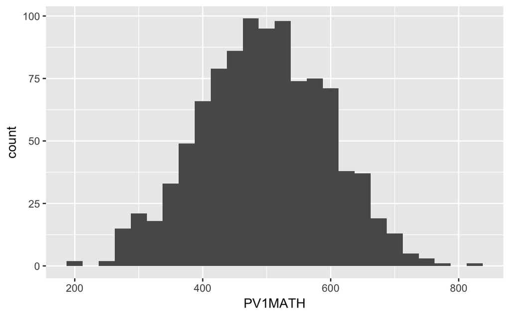

```r
library(tidyverse)
PISA_oz_sub <- read_csv("PISA_oz_sub.csv")
ggplot(PISA_oz_sub, aes(x=PV1MATH)) +
  geom_histogram(binwidth=25)
```

Describe the distribution of math scores. Discuss min, max, centre and shape.

```
The distribution is bell-shaped, ranging from 200-800 and centered at 500.
```

## Exercise 5 (3pts)

Make a bar chart of the number of televisions in the house.

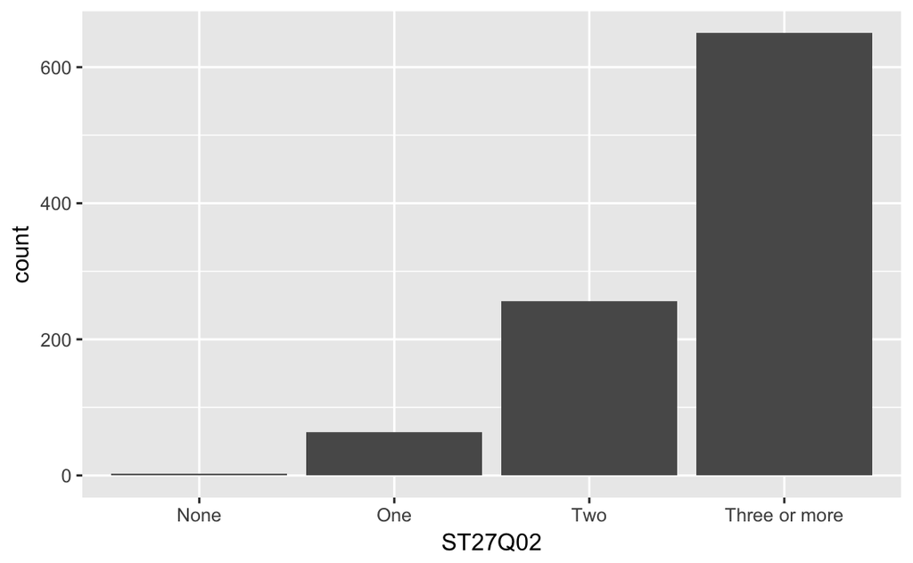

```r
PISA_oz_sub <- PISA_oz_sub %>%
  filter(!is.na(ST27Q02)) %>%
  mutate(ST27Q02=fct_relevel(ST27Q02,
      c("None", "One", "Two", "Three or more")))
ggplot(PISA_oz_sub, aes(x=ST27Q02)) + geom_bar()
```

1. Most households in the study have how many TVs? `3`
2. What happens to the plot if you neglect to do the first data transformation line especially the `mutate` function? Explain why this pre-processing is important.

```
The order of the categories is alphabetical (one, none, three or more, two), which makes no sense.
```

## Exercise 6 (3pts)

Make a side-by-side boxplot of the math scores by number of TVs, after removing the “None” category.

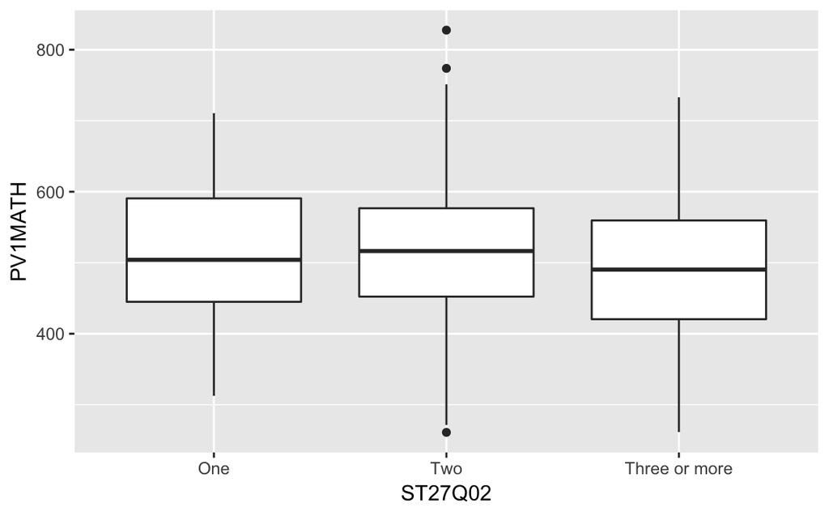

```r
PISA_oz_sub %>%
  filter(ST27Q02 != "None") %>%
  ggplot(aes(x=ST27Q02, y=PV1MATH)) + geom_boxplot()
```

1. Why should the “None” category be removed?

```
There are too few households without TVs to be able to say anything about the relationship with math scores.
```

2. Explain the relationship between TVs in the household and math scores? Is it helpful for math scores to have more TVs in the household?

```
The median math score is lower when there are three TVs and the Q1, Q3 are also lower. It looks like there is an adverse effect on math scores as number of TVs increase.
```

## Exercise 7 (3pts)

Modify the code to show reading scores (PV1READ) against the number of TVs. Explain what you learn about the relationship between these two variables.

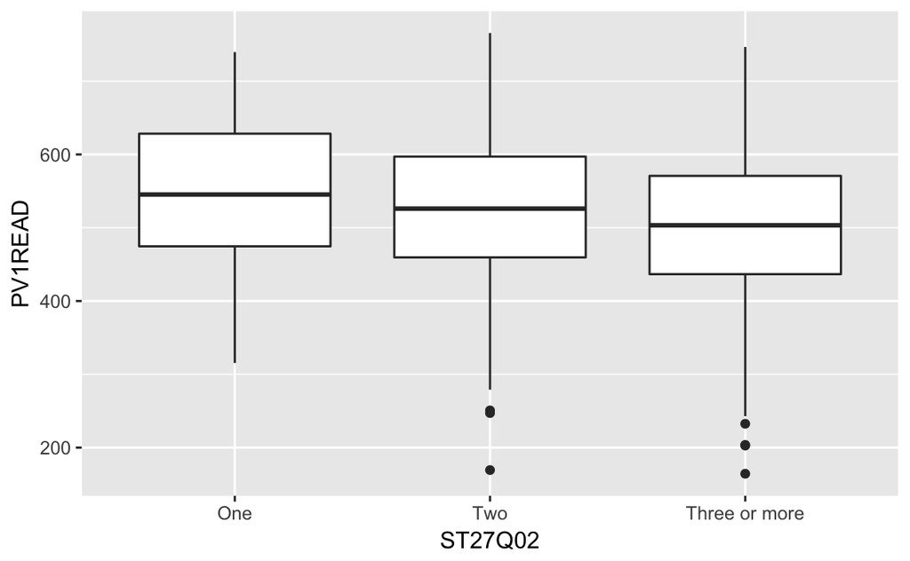

```r
PISA_oz_sub %>%
  filter(ST27Q02 != "None") %>%
  ggplot(aes(x=ST27Q02, y=PV1READ)) + geom_boxplot()
```

```
The same decline in reading scores are seen as household have more TVs.
```

## Exercise 8 (3pts)

Is the relationship between the number of books in the household and math scores similar to that of TVs? Make the appropriate plot to help you answer the question.

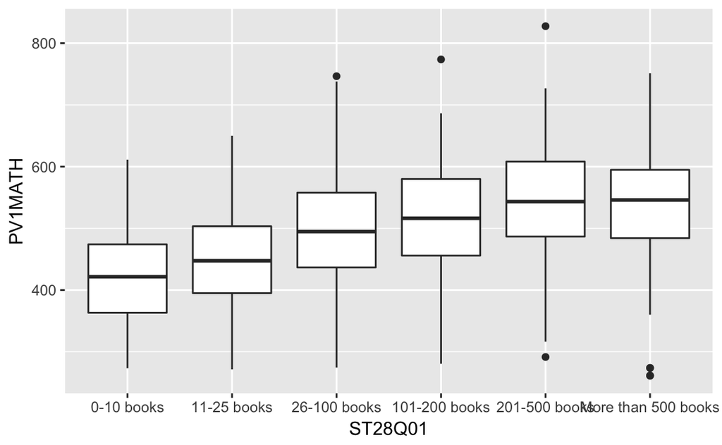

```r
PISA_oz_sub %>%
  filter(!is.na(ST28Q01)) %>%
  mutate(ST28Q01=fct_relevel(ST28Q01,
      c("0-10 books", "11-25 books", "26-100 books",
        "101-200 books", "201-500 books",
        "More than 500 books"))) %>%
  ggplot(aes(x=ST28Q01, y=PV1MATH)) + geom_boxplot()
```

```
The relationship between math scores and number of books in the household is entirely different to TVs. Mathe scores tend to increase, on average, with more books.
```

## Exercise 9 (3pts)

This is a count of the number of students responding to the question about classroom management and whether students listen.

```r
PISA_oz_sub %>%
  filter(!is.na(ST85Q01)) %>%
  mutate(ST85Q01=fct_relevel(ST85Q01,
      c("Strongly disagree", "Disagree", "Agree", "Strongly agree"))) %>%
  group_by(ST85Q01) %>%
  tally()
```

| ST85Q01 | n |
| --- | --- |
| Strongly disagree | 12 |
| Disagree | 63 |
| Agree | 351 |
| Strongly agree | 211 |

1. Would you report that students say that they mostly listen during class?

```
Yes! Most students respond strongly agree or agree to the statement.
```

2. What line in the code does the counting?

```
tally()
```

## Exercise 10 (3pts)

Make a mosaic plot of the classroom management responses, students listen, teacher keeps class orderly.

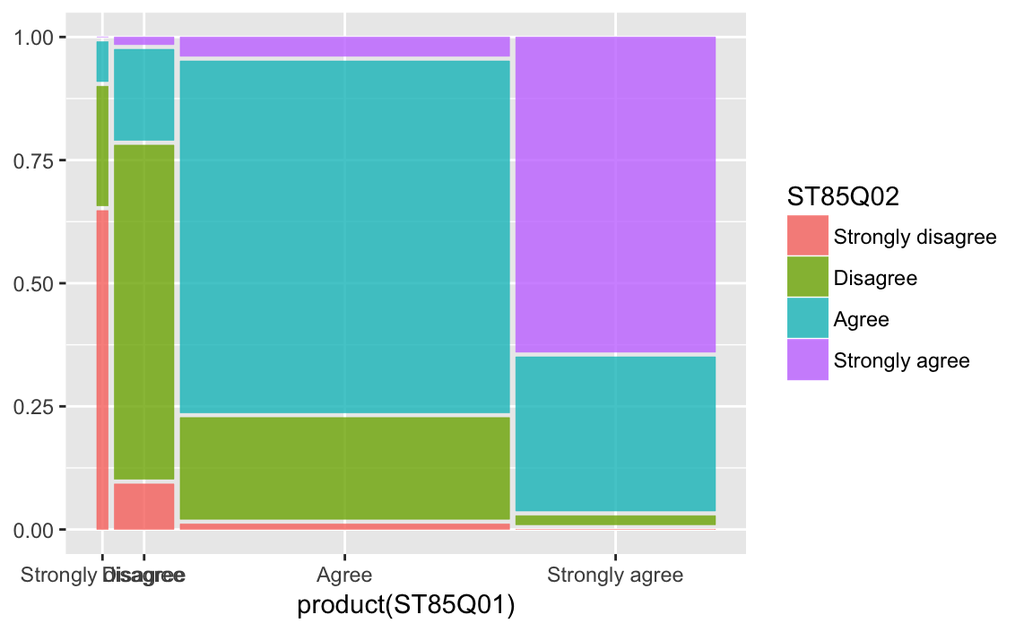

Explain the relationship between the two variables. Do students who strongly agree with one, tend to strongly agree with the other statement?

[output not shown]

## Exercise 11 (10pts)

Your turn to read the data dictionary, and come up with 5 more questions to ask about this data. Make the plots to answer these questions.